# Project: Investigate a Dataset - [TMDb Movie data]

- Introduction
- Data Wrangling
- Exploratory Data Analysis
- Conclusions

## Introduction

### Dataset Description

> This data set contains information about 10,000 movies collected from The Movie Database (TMDb), including user ratings and revenue.

### Dataset columns

> - id
> - imdb_id
> - popularity - Index indicating popularity
> - budget
> - revenue
> - original_title
> - cast - multiple values separated by pipe (|) characters
> - homepage - page of the movie
> - director - multiple values separated by pipe (|)
> - tagline
> - keywords - multiple values separated by pipe (|) characters
> - overview
> - runtime
> - genres - multiple values separated by pipe (|) characters
> - production_companies - multiple values separated by pipe (|) characters
> - release_date
> - vote_count
> - vote_average
> - release_year
> - budget_adj - budget of the associated movie in terms of 2010 dollars, accounting for inflation over time.
> - revenue_adj - revenue of the associated movie in terms of 2010 dollars, accounting for inflation over time

### Question(s) for Analysis

> 1. Which genres are most popular from year to year?
> 2. Which genres are associated with high revenue movies?
> 3. What actors are associated with high revenues movies?
> 4. What directors are associated with high revenues movies?
> 5. What production companies has the highest revenue?
> 6. What production company spend highest budget?
> 7. Is higher budget movies associated with higher revenue?
> 8. Is run time associated with revenue?
> 9. Is there correlation between user’s vote average and revenue?
> 10. Is there correlation between popularity and revenue?

```python
# Upgrade pandas to use dataframe.explode() function.
!pip install --upgrade pandas==0.25.0
```

[output not shown]

## Importing needed packages

```python
import numpy as np
import pandas as pd
import matplotlib.pyplot as plt
import seaborn as sns
% matplotlib inline
```

## Adjust Pandas display options

```python
pd.set_option('display.max_column', None)
```

## Defining needed functions

```python
def count_zeros(df):
    """
    Prints Zeros counts for every column in DataFrame

    Args:
        df: Pandas DataFrame

    Returns:
        View Zeros counts in every column.

    """
    for column_name in df.columns:
        Zeros_count = df[df[column_name] == 0][column_name].count()
        print('Column "{}" has {} Zeros'.format(column_name, Zeros_count))

def correct_date(date, year, sep= '/'):
    """
    Corrects date formats for in string format mm/dd/yy

    Args:
        date: date string to be corrected
        year: year for correction
        sep: seperator in date format

    Returns:
        corrected date in mm/dd/yyyy format.

    """
    date_list = date.split(sep)
    year_ind = int(date_list[-1])
    if year_ind+2000 > year:
        date_list[-1] = str(year_ind+1900)
        date = sep.join(date_list)
    else:
        date_list[-1] = str(year_ind+2000)
        date = sep.join(date_list)

    return date

def replace_zeros(df, columns):
    """
    Replaces zeros with column's median in one or multiple columns, The column's median is calculated for non Zero values
    to avoid deviation from actual distribution.

    Args:
        df: Pandas DataFrame to work on
        columns: columns to replace its Zeros

    Returns:
        Replaced dataframe as desired.

    """
    for column in columns:
        median_value = df[df[column] != 0].median()[column]
        df[column].replace(0, median_value, inplace= True)

def into_list(df, columns , sep):
    """
    Changes columns with list like values ,string seperated by a seperator, into python lists

    Args:
        df: Pandas DataFrame to work on
        columns: columns to turn its values into list
        sep: String seperator

    Returns:
        Changed dataframe values into list.

    """
    for column in columns:
        df[column]= df[column].apply(lambda x: x.split(sep))
```

## Data Wrangling

> **Assessing Data** - We are going to assess out dataset for the following:
> - Inspect data
> - Shape
> - NaN values
> - Duplicate rows
> - Data types
> - Outliers or abnormal values

> **Cleaning Data** - Based on problems found in data assessment

## Loading Dataset and inspecting data

```python
# Load your data and print out a few lines. Perform operations to inspect data
df = pd.read_csv('tmdb-movies.csv', encoding='UTF-8')
df.head()
```

|  | id | imdb_id | popularity | budget | revenue | original_title | cast | homepage | director | tagline | keywords | overview | runtime | genres | production_companies | release_date | vote_count | vote_average | release_year | budget_adj | revenue_adj |
| --- | --- | --- | --- | --- | --- | --- | --- | --- | --- | --- | --- | --- | --- | --- | --- | --- | --- | --- | --- | --- | --- |
| 0 | 135397 | tt0369610 | 32.985763 | 150000000 | 1513528810 | Jurassic World | Chris Pratt\|Bryce Dallas Howard\|Irrfan Khan\|Vi... | http://www.jurassicworld.com/ | Colin Trevorrow | The park is open. | monster\|dna\|tyrannosaurus rex\|velociraptor\|island | Twenty-two years after the events of Jurassic ... | 124 | Action\|Adventure\|Science Fiction\|Thriller | Universal Studios\|Amblin Entertainment\|Legenda... | 6/9/15 | 5562 | 6.5 | 2015 | 1.379999e+08 | 1.392446e+09 |
| 1 | 76341 | tt1392190 | 28.419936 | 150000000 | 378436354 | Mad Max: Fury Road | Tom Hardy\|Charlize Theron\|Hugh Keays-Byrne\|Nic... | http://www.madmaxmovie.com/ | George Miller | What a Lovely Day. | future\|chase\|post-apocalyptic\|dystopia\|australia | An apocalyptic story set in the furthest reach... | 120 | Action\|Adventure\|Science Fiction\|Thriller | Village Roadshow Pictures\|Kennedy Miller Produ... | 5/13/15 | 6185 | 7.1 | 2015 | 1.379999e+08 | 3.481613e+08 |
| 2 | 262500 | tt2908446 | 13.112507 | 110000000 | 295238201 | Insurgent | Shailene Woodley\|Theo James\|Kate Winslet\|Ansel... | http://www.thedivergentseries.movie/#insurgent | Robert Schwentke | One Choice Can Destroy You | based on novel\|revolution\|dystopia\|sequel\|dyst... | Beatrice Prior must confront her inner demons ... | 119 | Adventure\|Science Fiction\|Thriller | Summit Entertainment\|Mandeville Films\|Red Wago... | 3/18/15 | 2480 | 6.3 | 2015 | 1.012000e+08 | 2.716190e+08 |
| 3 | 140607 | tt2488496 | 11.173104 | 200000000 | 2068178225 | Star Wars: The Force Awakens | Harrison Ford\|Mark Hamill\|Carrie Fisher\|Adam D... | http://www.starwars.com/films/star-wars-episod... | J.J. Abrams | Every generation has a story. | android\|spaceship\|jedi\|space opera\|3d | Thirty years after defeating the Galactic Empi... | 136 | Action\|Adventure\|Science Fiction\|Fantasy | Lucasfilm\|Truenorth Productions\|Bad Robot | 12/15/15 | 5292 | 7.5 | 2015 | 1.839999e+08 | 1.902723e+09 |
| 4 | 168259 | tt2820852 | 9.335014 | 190000000 | 1506249360 | Furious 7 | Vin Diesel\|Paul Walker\|Jason Statham\|Michelle ... | http://www.furious7.com/ | James Wan | Vengeance Hits Home | car race\|speed\|revenge\|suspense\|car | Deckard Shaw seeks revenge against Dominic Tor... | 137 | Action\|Crime\|Thriller | Universal Pictures\|Original Film\|Media Rights ... | 4/1/15 | 2947 | 7.3 | 2015 | 1.747999e+08 | 1.385749e+09 |

```python
df.shape
```

```
(10866, 21)
```

```python
df.describe()
```

|  | id | popularity | budget | revenue | runtime | vote_count | vote_average | release_year | budget_adj | revenue_adj |
| --- | --- | --- | --- | --- | --- | --- | --- | --- | --- | --- |
| count | 10866.000000 | 10866.000000 | 1.086600e+04 | 1.086600e+04 | 10866.000000 | 10866.000000 | 10866.000000 | 10866.000000 | 1.086600e+04 | 1.086600e+04 |
| mean | 66064.177434 | 0.646441 | 1.462570e+07 | 3.982332e+07 | 102.070863 | 217.389748 | 5.974922 | 2001.322658 | 1.755104e+07 | 5.136436e+07 |
| std | 92130.136561 | 1.000185 | 3.091321e+07 | 1.170035e+08 | 31.381405 | 575.619058 | 0.935142 | 12.812941 | 3.430616e+07 | 1.446325e+08 |
| min | 5.000000 | 0.000065 | 0.000000e+00 | 0.000000e+00 | 0.000000 | 10.000000 | 1.500000 | 1960.000000 | 0.000000e+00 | 0.000000e+00 |
| 25% | 10596.250000 | 0.207583 | 0.000000e+00 | 0.000000e+00 | 90.000000 | 17.000000 | 5.400000 | 1995.000000 | 0.000000e+00 | 0.000000e+00 |
| 50% | 20669.000000 | 0.383856 | 0.000000e+00 | 0.000000e+00 | 99.000000 | 38.000000 | 6.000000 | 2006.000000 | 0.000000e+00 | 0.000000e+00 |
| 75% | 75610.000000 | 0.713817 | 1.500000e+07 | 2.400000e+07 | 111.000000 | 145.750000 | 6.600000 | 2011.000000 | 2.085325e+07 | 3.369710e+07 |
| max | 417859.000000 | 32.985763 | 4.250000e+08 | 2.781506e+09 | 900.000000 | 9767.000000 | 9.200000 | 2015.000000 | 4.250000e+08 | 2.827124e+09 |

```python
df.info()
```

```
<class 'pandas.core.frame.DataFrame'>
RangeIndex: 10866 entries, 0 to 10865
Data columns (total 21 columns):
id                      10866 non-null int64
imdb_id                 10856 non-null object
popularity              10866 non-null float64
budget                  10866 non-null int64
revenue                 10866 non-null int64
original_title          10866 non-null object
cast                    10790 non-null object
homepage                2936 non-null object
director                10822 non-null object
tagline                 8042 non-null object
keywords                9373 non-null object
overview                10862 non-null object
runtime                 10866 non-null int64
genres                  10843 non-null object
production_companies    9836 non-null object
release_date            10866 non-null object
vote_count              10866 non-null int64
vote_average            10866 non-null float64
release_year            10866 non-null int64
budget_adj              10866 non-null float64
revenue_adj             10866 non-null float64
dtypes: float64(4), int64(6), object(11)
memory usage: 1.7+ MB
```

```python
df.duplicated().sum()
```

```
1
```

```python
df.original_title.duplicated().sum()
```

```
295
```

```python
count_zeros(df)
```

```
Column "id" has 0 Zeros
Column "imdb_id" has 0 Zeros
Column "popularity" has 0 Zeros
Column "budget" has 5696 Zeros
Column "revenue" has 6016 Zeros
Column "original_title" has 0 Zeros
Column "cast" has 0 Zeros
Column "homepage" has 0 Zeros
Column "director" has 0 Zeros
Column "tagline" has 0 Zeros
Column "keywords" has 0 Zeros
Column "overview" has 0 Zeros
Column "runtime" has 31 Zeros
Column "genres" has 0 Zeros
Column "production_companies" has 0 Zeros
Column "release_date" has 0 Zeros
Column "vote_count" has 0 Zeros
Column "vote_average" has 0 Zeros
Column "release_year" has 0 Zeros
Column "budget_adj" has 5696 Zeros
Column "revenue_adj" has 6016 Zeros
```

## Dataset observed issues:

> 1. NaN values in cast, homepage, director, tagline, keywords, overview, genres and production_companies columns
> 2. Duplicate rows
> 3. Duplicate in original_title column
> 4. Wrong data types in release_date
> 5. Zeros , probably unknown values, in runtime, budget, revenue, budget_adj and revenue_adj columns
> 6. Columns that has list like values seperated with pipe (|) charachter

## Data Cleaning

### 1. Drop unnecessary columns

```python
# First we create a copy of df to work with
df_cleaned= df.copy()

#Second we create a list with to columns to be removed
removed_columns= ['id', 'imdb_id', 'budget', 'revenue', 'homepage', 'tagline', 'keywords', 'overview']
df_cleaned.drop(removed_columns, axis= 1, inplace= True)

#Check df_cleaned now
df_cleaned.head()
```

|  | popularity | original_title | cast | director | runtime | genres | production_companies | release_date | vote_count | vote_average | release_year | budget_adj | revenue_adj |
| --- | --- | --- | --- | --- | --- | --- | --- | --- | --- | --- | --- | --- | --- |
| 0 | 32.985763 | Jurassic World | Chris Pratt\|Bryce Dallas Howard\|Irrfan Khan\|Vi... | Colin Trevorrow | 124 | Action\|Adventure\|Science Fiction\|Thriller | Universal Studios\|Amblin Entertainment\|Legenda... | 6/9/15 | 5562 | 6.5 | 2015 | 1.379999e+08 | 1.392446e+09 |
| 1 | 28.419936 | Mad Max: Fury Road | Tom Hardy\|Charlize Theron\|Hugh Keays-Byrne\|Nic... | George Miller | 120 | Action\|Adventure\|Science Fiction\|Thriller | Village Roadshow Pictures\|Kennedy Miller Produ... | 5/13/15 | 6185 | 7.1 | 2015 | 1.379999e+08 | 3.481613e+08 |
| 2 | 13.112507 | Insurgent | Shailene Woodley\|Theo James\|Kate Winslet\|Ansel... | Robert Schwentke | 119 | Adventure\|Science Fiction\|Thriller | Summit Entertainment\|Mandeville Films\|Red Wago... | 3/18/15 | 2480 | 6.3 | 2015 | 1.012000e+08 | 2.716190e+08 |
| 3 | 11.173104 | Star Wars: The Force Awakens | Harrison Ford\|Mark Hamill\|Carrie Fisher\|Adam D... | J.J. Abrams | 136 | Action\|Adventure\|Science Fiction\|Fantasy | Lucasfilm\|Truenorth Productions\|Bad Robot | 12/15/15 | 5292 | 7.5 | 2015 | 1.839999e+08 | 1.902723e+09 |
| 4 | 9.335014 | Furious 7 | Vin Diesel\|Paul Walker\|Jason Statham\|Michelle ... | James Wan | 137 | Action\|Crime\|Thriller | Universal Pictures\|Original Film\|Media Rights ... | 4/1/15 | 2947 | 7.3 | 2015 | 1.747999e+08 | 1.385749e+09 |

> We removed budget and revenue columns as we are going to work with **budget_adj and revenue_adj to account for inflation over time**.

### 2. Drop duplicate rows

```python
df_cleaned.drop_duplicates(inplace= True)

#Check if there is no more duplicates
df_cleaned.duplicated().sum()
```

```
0
```

### 3. Dealing with NaN Values

```python
#Determining NaN Values in every column
df_cleaned.isnull().sum()
```

```
popularity                 0
original_title             0
cast                      76
director                  44
runtime                    0
genres                    23
production_companies    1030
release_date               0
vote_count                 0
vote_average               0
release_year               0
budget_adj                 0
revenue_adj                0
dtype: int64
```

```python
#Assess NaN Values in production_companies column
#Filtering rows with 'production_companies' NaN values
df_companies_nulls = df_cleaned[df_cleaned['production_companies'].isnull()]
#Find Columns that has Zero values in df_companies_nulls
count_zeros(df_companies_nulls)
```

```
Column "popularity" has 0 Zeros
Column "original_title" has 0 Zeros
Column "cast" has 0 Zeros
Column "director" has 0 Zeros
Column "runtime" has 18 Zeros
Column "genres" has 0 Zeros
Column "production_companies" has 0 Zeros
Column "release_date" has 0 Zeros
Column "vote_count" has 0 Zeros
Column "vote_average" has 0 Zeros
Column "release_year" has 0 Zeros
Column "budget_adj" has 894 Zeros
Column "revenue_adj" has 934 Zeros
```

> - NaN values count in cast, director and genres are insignificant so we are going to delete it.
> - As for production_companies column from total of 1030 rows with NaN values 934 rows has Zero values in revenue_adj column and 894 rows has Zero values in budget_adj column. We going to delete these rows because filling NaN values will be inaccurate and we can't assume production companies, budget or revenue correctly.
> - Number of rows with NaN values is around 10% from the total rows so it's fine to delete them

```python
#Dropping NaN values
df_cleaned.dropna(axis= 0, inplace= True)

#Check DataDrame for any null values
df_cleaned.isnull().sum().any()
```

```
False
```

### 4. Dealing with duplicates in original_title columns

> Many movies has the same name like Hamlet was released by the same name in 1990, 1996, 2000 and 2009.  
> We are fixing this by concatenating movies title with year of release.

```python
df_cleaned[df_cleaned['original_title'] == 'Hamlet'].release_year
```

```
1890     2009
8573     1996
8797     2000
10106    1990
Name: release_year, dtype: int64
```

```python
#Joining original_title and release_year
df_cleaned['original_title'] = df_cleaned['original_title'] + ' - ' + df_cleaned['release_year'].astype(str)

#Check for duplicates in 'original_title' columns
df_cleaned[df_cleaned['original_title'].duplicated()]
```

|  | popularity | original_title | cast | director | runtime | genres | production_companies | release_date | vote_count | vote_average | release_year | budget_adj | revenue_adj |
| --- | --- | --- | --- | --- | --- | --- | --- | --- | --- | --- | --- | --- | --- |
| 5748 | 0.336081 | 1 - 2013 | Rhys Wakefield\|Logan Miller\|Ashley Hinshaw\|Nat... | Dennis Iliadis | 95 | Thriller\|Science Fiction | Process Productions | 9/20/13 | 49 | 5.1 | 2013 | 0.0 | 0.0 |
| 8646 | 0.161600 | Emma - 1996 | Kate Beckinsale\|Bernard Hepton\|Mark Strong\|Sam... | Diarmuid Lawrence | 107 | TV Movie\|Comedy\|Drama\|Romance | Meridian Broadcasting Ltd | 8/1/96 | 15 | 6.6 | 1996 | 0.0 | 0.0 |

> There are 4 movies by the same name release in the same year. That's fine. We'll leave them as they are.

### 5. Changing data types in release_date

```python
#First we correct date format from mm/dd/yy to mm/dd/yyyy
df_cleaned['release_date'] = df_cleaned.release_date.apply(correct_date, year= 2015)
```

```python
#Check df_cleaned now
df_cleaned.head()
```

|  | popularity | original_title | cast | director | runtime | genres | production_companies | release_date | vote_count | vote_average | release_year | budget_adj | revenue_adj |
| --- | --- | --- | --- | --- | --- | --- | --- | --- | --- | --- | --- | --- | --- |
| 0 | 32.985763 | Jurassic World - 2015 | Chris Pratt\|Bryce Dallas Howard\|Irrfan Khan\|Vi... | Colin Trevorrow | 124 | Action\|Adventure\|Science Fiction\|Thriller | Universal Studios\|Amblin Entertainment\|Legenda... | 6/9/2015 | 5562 | 6.5 | 2015 | 1.379999e+08 | 1.392446e+09 |
| 1 | 28.419936 | Mad Max: Fury Road - 2015 | Tom Hardy\|Charlize Theron\|Hugh Keays-Byrne\|Nic... | George Miller | 120 | Action\|Adventure\|Science Fiction\|Thriller | Village Roadshow Pictures\|Kennedy Miller Produ... | 5/13/2015 | 6185 | 7.1 | 2015 | 1.379999e+08 | 3.481613e+08 |
| 2 | 13.112507 | Insurgent - 2015 | Shailene Woodley\|Theo James\|Kate Winslet\|Ansel... | Robert Schwentke | 119 | Adventure\|Science Fiction\|Thriller | Summit Entertainment\|Mandeville Films\|Red Wago... | 3/18/2015 | 2480 | 6.3 | 2015 | 1.012000e+08 | 2.716190e+08 |
| 3 | 11.173104 | Star Wars: The Force Awakens - 2015 | Harrison Ford\|Mark Hamill\|Carrie Fisher\|Adam D... | J.J. Abrams | 136 | Action\|Adventure\|Science Fiction\|Fantasy | Lucasfilm\|Truenorth Productions\|Bad Robot | 12/15/2015 | 5292 | 7.5 | 2015 | 1.839999e+08 | 1.902723e+09 |
| 4 | 9.335014 | Furious 7 - 2015 | Vin Diesel\|Paul Walker\|Jason Statham\|Michelle ... | James Wan | 137 | Action\|Crime\|Thriller | Universal Pictures\|Original Film\|Media Rights ... | 4/1/2015 | 2947 | 7.3 | 2015 | 1.747999e+08 | 1.385749e+09 |

```python
#change 'release_date' to datetime
df_cleaned['release_date'] = pd.to_datetime(df_cleaned['release_date'])
```

```python
#check data types now
df_cleaned.dtypes
```

```
popularity                     float64
original_title                  object
cast                            object
director                        object
runtime                          int64
genres                          object
production_companies            object
release_date            datetime64[ns]
vote_count                       int64
vote_average                   float64
release_year                     int64
budget_adj                     float64
revenue_adj                    float64
dtype: object
```

### 6. Dealing with zero unknown values

```python
#check zero values
count_zeros(df_cleaned)
```

```
Column "popularity" has 0 Zeros
Column "original_title" has 0 Zeros
Column "cast" has 0 Zeros
Column "director" has 0 Zeros
Column "runtime" has 13 Zeros
Column "genres" has 0 Zeros
Column "production_companies" has 0 Zeros
Column "release_date" has 0 Zeros
Column "vote_count" has 0 Zeros
Column "vote_average" has 0 Zeros
Column "release_year" has 0 Zeros
Column "budget_adj" has 4751 Zeros
Column "revenue_adj" has 5022 Zeros
```

```python
#replace zero values with median
replace_zeros(df_cleaned, ['runtime','budget_adj','revenue_adj'])
```

```python
#check for zero values again
count_zeros(df_cleaned)
```

```
Column "popularity" has 0 Zeros
Column "original_title" has 0 Zeros
Column "cast" has 0 Zeros
Column "director" has 0 Zeros
Column "runtime" has 0 Zeros
Column "genres" has 0 Zeros
Column "production_companies" has 0 Zeros
Column "release_date" has 0 Zeros
Column "vote_count" has 0 Zeros
Column "vote_average" has 0 Zeros
Column "release_year" has 0 Zeros
Column "budget_adj" has 0 Zeros
Column "revenue_adj" has 0 Zeros
```

> In the previous steps we choose to fill Zeros in 'runtime','budget_adj' and 'revenue_adj' columns with their median for the following reasons:
> - Zeros are unknown values as no movie has zero runtime, budget or revenue_adj.
> - Rows with zero columns has other needed values in the rest of the columns.
> - Count of rows with Zero columns are more than 45% of total rows count so deleting them would affect accuracy of analysis
> - We used median for filling Zeros as it's less sensitive to outliers and won't affect whole dataset distribution and mean significantly

### 7. Columns that has list like values seperated with pipe (|) charachter

> We need to change these into python lists so we can use pandas.DataFrame.explode method later

```python
#Turning list like values in 'cast', 'genres' and 'production_companies' columns into python lists
into_list(df_cleaned, ['cast', 'director', 'genres', 'production_companies'], '|')
```

```python
#Check df_cleaned now
df_cleaned.head()
```

|  | popularity | original_title | cast | director | runtime | genres | production_companies | release_date | vote_count | vote_average | release_year | budget_adj | revenue_adj |
| --- | --- | --- | --- | --- | --- | --- | --- | --- | --- | --- | --- | --- | --- |
| 0 | 32.985763 | Jurassic World - 2015 | [Chris Pratt, Bryce Dallas Howard, Irrfan Khan... | [Colin Trevorrow] | 124 | [Action, Adventure, Science Fiction, Thriller] | [Universal Studios, Amblin Entertainment, Lege... | 2015-06-09 | 5562 | 6.5 | 2015 | 1.379999e+08 | 1.392446e+09 |
| 1 | 28.419936 | Mad Max: Fury Road - 2015 | [Tom Hardy, Charlize Theron, Hugh Keays-Byrne,... | [George Miller] | 120 | [Action, Adventure, Science Fiction, Thriller] | [Village Roadshow Pictures, Kennedy Miller Pro... | 2015-05-13 | 6185 | 7.1 | 2015 | 1.379999e+08 | 3.481613e+08 |
| 2 | 13.112507 | Insurgent - 2015 | [Shailene Woodley, Theo James, Kate Winslet, A... | [Robert Schwentke] | 119 | [Adventure, Science Fiction, Thriller] | [Summit Entertainment, Mandeville Films, Red W... | 2015-03-18 | 2480 | 6.3 | 2015 | 1.012000e+08 | 2.716190e+08 |
| 3 | 11.173104 | Star Wars: The Force Awakens - 2015 | [Harrison Ford, Mark Hamill, Carrie Fisher, Ad... | [J.J. Abrams] | 136 | [Action, Adventure, Science Fiction, Fantasy] | [Lucasfilm, Truenorth Productions, Bad Robot] | 2015-12-15 | 5292 | 7.5 | 2015 | 1.839999e+08 | 1.902723e+09 |
| 4 | 9.335014 | Furious 7 - 2015 | [Vin Diesel, Paul Walker, Jason Statham, Miche... | [James Wan] | 137 | [Action, Crime, Thriller] | [Universal Pictures, Original Film, Media Righ... | 2015-04-01 | 2947 | 7.3 | 2015 | 1.747999e+08 | 1.385749e+09 |

```python
#Reset the index of dataframe
df_cleaned.reset_index(drop= True, inplace= True)
```

## Exploratory Data Analysis

### 1. Which genres are most popular from year to year?

> We're determining most popular genre by using the count of produced movies in each genre across the years. We can't use popularity column as it represents current visits and votes not the actual popularity the year movie is produced.  
> First we need to create df_genres as a copy of df_cleaned then we use pandas.DataFrame.explode method to transform each genre of the list to a row

```python
df_genres = df_cleaned.copy()
```

```python
df_genres = df_genres.explode('genres')
```

```python
df_genres.head()
```

|  | popularity | original_title | cast | director | runtime | genres | production_companies | release_date | vote_count | vote_average | release_year | budget_adj | revenue_adj |
| --- | --- | --- | --- | --- | --- | --- | --- | --- | --- | --- | --- | --- | --- |
| 0 | 32.985763 | Jurassic World - 2015 | [Chris Pratt, Bryce Dallas Howard, Irrfan Khan... | [Colin Trevorrow] | 124 | Action | [Universal Studios, Amblin Entertainment, Lege... | 2015-06-09 | 5562 | 6.5 | 2015 | 1.379999e+08 | 1.392446e+09 |
| 0 | 32.985763 | Jurassic World - 2015 | [Chris Pratt, Bryce Dallas Howard, Irrfan Khan... | [Colin Trevorrow] | 124 | Adventure | [Universal Studios, Amblin Entertainment, Lege... | 2015-06-09 | 5562 | 6.5 | 2015 | 1.379999e+08 | 1.392446e+09 |
| 0 | 32.985763 | Jurassic World - 2015 | [Chris Pratt, Bryce Dallas Howard, Irrfan Khan... | [Colin Trevorrow] | 124 | Science Fiction | [Universal Studios, Amblin Entertainment, Lege... | 2015-06-09 | 5562 | 6.5 | 2015 | 1.379999e+08 | 1.392446e+09 |
| 0 | 32.985763 | Jurassic World - 2015 | [Chris Pratt, Bryce Dallas Howard, Irrfan Khan... | [Colin Trevorrow] | 124 | Thriller | [Universal Studios, Amblin Entertainment, Lege... | 2015-06-09 | 5562 | 6.5 | 2015 | 1.379999e+08 | 1.392446e+09 |
| 1 | 28.419936 | Mad Max: Fury Road - 2015 | [Tom Hardy, Charlize Theron, Hugh Keays-Byrne,... | [George Miller] | 120 | Action | [Village Roadshow Pictures, Kennedy Miller Pro... | 2015-05-13 | 6185 | 7.1 | 2015 | 1.379999e+08 | 3.481613e+08 |

```python
#check 'release_year' values
print(df_genres['release_year'].unique().min())
print(df_genres['release_year'].unique().max())
```

```
1960
2015
```

```python
#Determine the mode of genres for every year
df_genres.groupby('release_year').genres.apply(lambda x: x.mode())
```

```
release_year
1960          0     Drama
1961          0     Drama
1962          0     Drama
1963          0    Comedy
              1     Drama
1964          0     Drama
1965          0     Drama
1966          0    Comedy
              1     Drama
1967          0    Comedy
              1     Drama
1968          0     Drama
1969          0     Drama
1970          0     Drama
```

[output cut: 47 more lines]

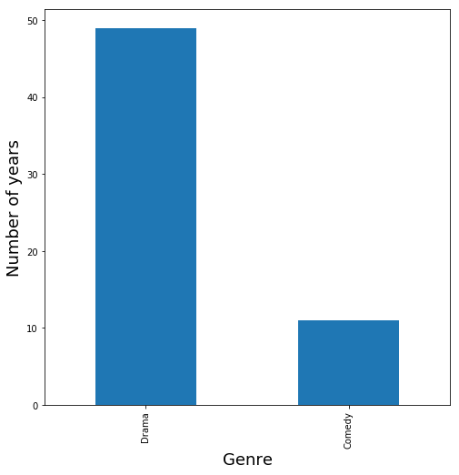

```python
#Count of years that each genre has been most popular visualised in bar chart
df_genres.groupby('release_year').genres.apply(lambda x: x.mode()).value_counts().plot(kind='bar', figsize= (8,8));
plt.xlabel('Genre', fontsize=18)
plt.ylabel('Number of years', fontsize=18)
sns.set_style('darkgrid');
```

```python
#We can also create barplot for count for each genre a cross time frame of the dataset
#First We group by genre aggregating with count of movies titles
genres_count = df_genres.groupby(['genres'])['original_title'].agg(movie_count= 'count').sort_values(by= 'movie_count', ascending= False)
genres_count
```

| genres | movie_count |
| --- | --- |
| Drama | 4364 |
| Comedy | 3433 |
| Thriller | 2746 |
| Action | 2235 |
| Romance | 1570 |
| Horror | 1526 |
| Adventure | 1384 |
| Crime | 1299 |
| Science Fiction | 1136 |
| Family | 1095 |
| Fantasy | 840 |
| Mystery | 773 |
| Animation | 617 |
| Music | 339 |
| Documentary | 317 |
| History | 306 |
| War | 258 |
| Western | 160 |
| TV Movie | 132 |
| Foreign | 120 |

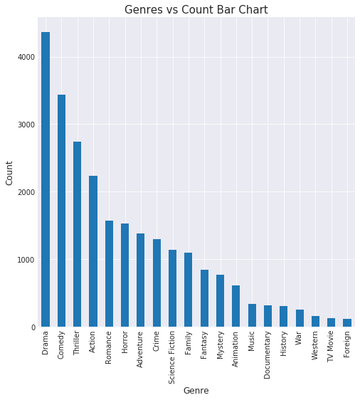

```python
#Visualise genres_count in a barplot
genres_count.plot(kind= 'bar',figsize= (8,8), legend= False)
plt.xlabel('Genre', fontsize= 12)
plt.ylabel('Count', fontsize= 12)
plt.title('Genres vs Count Bar Chart',fontsize= 15);
```

> Based on previous **Drama** Genre has been the most popular genre for the most of the past years.

### 2. Which genres are associated with high revenue movies?

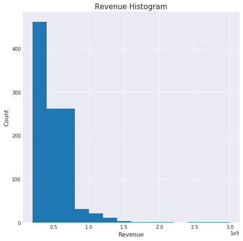

```python
#First lets plot a histogram showing revenue distribution
#working with origianl cleanded data
df_cleaned['revenue_adj'].hist(bins= [0.2e9,0.4e9,0.8e9,1e9,1.2e9,1.4e9,1.6e9,1.8e9,2e9,2.2e9,2.4e9,2.6e9,2.8e9,3e9], figsize= (8,8))
plt.xlabel('Revenue', fontsize= 12)
plt.ylabel('Count', fontsize= 12)
plt.title('Revenue Histogram',fontsize= 15);
```

```python
#View Statistical info about revenue
df_cleaned['revenue_adj'].describe()
```

```
count    9.772000e+03
mean     8.061484e+07
std      1.441298e+08
min      2.370705e+00
25%      4.584735e+07
50%      4.584735e+07
75%      4.584735e+07
max      2.827124e+09
Name: revenue_adj, dtype: float64
```

> Based on the previous revenues distribution appears to be right skewed.

```python
#Using df_genres group by genres and aggregate using revenue_adj mean
genres_revenue = df_genres.groupby('genres').revenue_adj.agg(avg_revenue= 'mean')
#Sort genres_revenue in descending order
genres_revenue = genres_revenue.sort_values(by= 'avg_revenue', ascending= False)
genres_revenue
```

| genres | avg_revenue |
| --- | --- |
| Adventure | 1.687494e+08 |
| Fantasy | 1.421291e+08 |
| Animation | 1.249477e+08 |
| Family | 1.233616e+08 |
| Action | 1.180572e+08 |
| Science Fiction | 1.163688e+08 |
| War | 9.474333e+07 |
| Thriller | 8.087129e+07 |
| Music | 7.802809e+07 |
| Crime | 7.769718e+07 |
| Comedy | 7.556908e+07 |
| History | 7.554527e+07 |
| Mystery | 7.481474e+07 |
| Western | 7.476379e+07 |
| Romance | 7.329018e+07 |
| Drama | 6.649504e+07 |
| Horror | 5.502828e+07 |
| TV Movie | 4.594236e+07 |
| Foreign | 3.929954e+07 |
| Documentary | 3.822182e+07 |

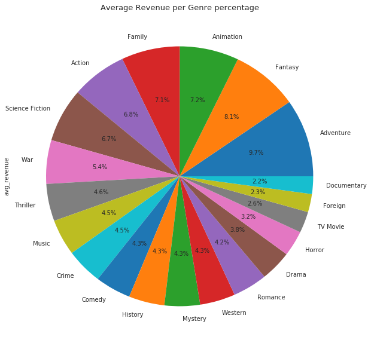

```python
#Visualizing data in a pie chart
genres_revenue.plot.pie(y= 'avg_revenue',autopct='%1.1f%%' , figsize=(10,10), legend= False)
plt.title('Average Revenue per Genre percentage', fontsize= 13);
```

> Based on the previous **Adventure** genre has the highest average revenue

### 3. What actors are associated with high revenues movies?

```python
#Create df_actors as a copy of df_cleaned then we use pandas.DataFrame.explode
df_actors = df_cleaned.copy()
```

```python
#explode method to transform each actor of the cast to a row
df_actors = df_actors.explode('cast')
df_actors.head()
```

|  | popularity | original_title | cast | director | runtime | genres | production_companies | release_date | vote_count | vote_average | release_year | budget_adj | revenue_adj |
| --- | --- | --- | --- | --- | --- | --- | --- | --- | --- | --- | --- | --- | --- |
| 0 | 32.985763 | Jurassic World - 2015 | Chris Pratt | [Colin Trevorrow] | 124 | [Action, Adventure, Science Fiction, Thriller] | [Universal Studios, Amblin Entertainment, Lege... | 2015-06-09 | 5562 | 6.5 | 2015 | 1.379999e+08 | 1.392446e+09 |
| 0 | 32.985763 | Jurassic World - 2015 | Bryce Dallas Howard | [Colin Trevorrow] | 124 | [Action, Adventure, Science Fiction, Thriller] | [Universal Studios, Amblin Entertainment, Lege... | 2015-06-09 | 5562 | 6.5 | 2015 | 1.379999e+08 | 1.392446e+09 |
| 0 | 32.985763 | Jurassic World - 2015 | Irrfan Khan | [Colin Trevorrow] | 124 | [Action, Adventure, Science Fiction, Thriller] | [Universal Studios, Amblin Entertainment, Lege... | 2015-06-09 | 5562 | 6.5 | 2015 | 1.379999e+08 | 1.392446e+09 |
| 0 | 32.985763 | Jurassic World - 2015 | Vincent D'Onofrio | [Colin Trevorrow] | 124 | [Action, Adventure, Science Fiction, Thriller] | [Universal Studios, Amblin Entertainment, Lege... | 2015-06-09 | 5562 | 6.5 | 2015 | 1.379999e+08 | 1.392446e+09 |
| 0 | 32.985763 | Jurassic World - 2015 | Nick Robinson | [Colin Trevorrow] | 124 | [Action, Adventure, Science Fiction, Thriller] | [Universal Studios, Amblin Entertainment, Lege... | 2015-06-09 | 5562 | 6.5 | 2015 | 1.379999e+08 | 1.392446e+09 |

```python
#Group by cast and using aggregation of revenue mean
actors_revenue = df_actors.groupby('cast').revenue_adj.agg(avg_revenue= 'mean')
#Sort actors_revenue in descending order to get top 20 actors
actors_revenue = actors_revenue.sort_values(by= 'avg_revenue', ascending= False)
#Top 20 actors according to their average revenue
actors_revenue = actors_revenue.iloc[0:20]
actors_revenue
```

| cast | avg_revenue |
| --- | --- |
| Daisy Ridley | 1.902723e+09 |
| Robert MacNaughton | 1.791694e+09 |
| Ben Wright | 1.574815e+09 |
| J. Pat O'Malley | 1.574815e+09 |
| Martha Wentworth | 1.574815e+09 |
| Betty Lou Gerson | 1.574815e+09 |
| Bob Peck | 1.388863e+09 |
| Louis Prima | 1.345551e+09 |
| Richard S. Castellano | 1.277914e+09 |
| Santino Fontana | 1.192711e+09 |
| Peggy Wood | 1.129535e+09 |
| Richard Haydn | 1.129535e+09 |
| Eleanor Parker | 1.129535e+09 |
| Jason Miller | 1.116226e+09 |
| FranÃ§ois Truffaut | 1.092965e+09 |
| Adolfo Celi | 9.771535e+08 |
| Claudine Auger | 9.771535e+08 |
| Luciana Paluzzi | 9.771535e+08 |
| Rik Van Nutter | 9.771535e+08 |
| Anthony Daniels | 9.080975e+08 |

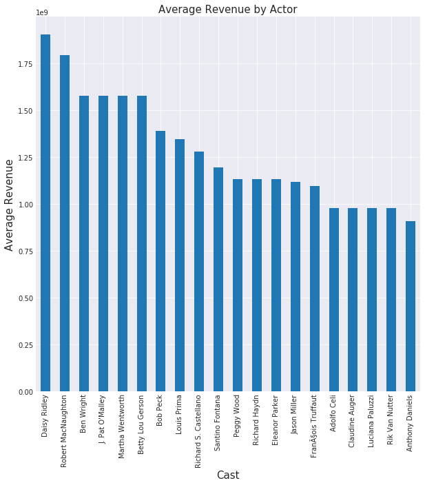

```python
#Visualizing our data
actors_revenue.plot(kind= 'bar', figsize= (10,10), legend=False);
plt.xlabel('Cast', fontsize = 15)
plt.ylabel('Average Revenue', fontsize = 15)
plt.title("Average Revenue by Actor", fontsize = 15);
```

> Based on the previous **Daisy Ridley** has the highest average revenue between actors

### 4. What directors are associated with high revenues movies?

```python
#Create df_directors as a copy of df_cleaned to work with and not to affect original cleaned data
df_directors = df_cleaned.copy()
```

```python
#explode method to transform each director of the directors to a row
df_directors = df_directors.explode('director')
df_directors.head()
```

|  | popularity | original_title | cast | director | runtime | genres | production_companies | release_date | vote_count | vote_average | release_year | budget_adj | revenue_adj |
| --- | --- | --- | --- | --- | --- | --- | --- | --- | --- | --- | --- | --- | --- |
| 0 | 32.985763 | Jurassic World - 2015 | [Chris Pratt, Bryce Dallas Howard, Irrfan Khan... | Colin Trevorrow | 124 | [Action, Adventure, Science Fiction, Thriller] | [Universal Studios, Amblin Entertainment, Lege... | 2015-06-09 | 5562 | 6.5 | 2015 | 1.379999e+08 | 1.392446e+09 |
| 1 | 28.419936 | Mad Max: Fury Road - 2015 | [Tom Hardy, Charlize Theron, Hugh Keays-Byrne,... | George Miller | 120 | [Action, Adventure, Science Fiction, Thriller] | [Village Roadshow Pictures, Kennedy Miller Pro... | 2015-05-13 | 6185 | 7.1 | 2015 | 1.379999e+08 | 3.481613e+08 |
| 2 | 13.112507 | Insurgent - 2015 | [Shailene Woodley, Theo James, Kate Winslet, A... | Robert Schwentke | 119 | [Adventure, Science Fiction, Thriller] | [Summit Entertainment, Mandeville Films, Red W... | 2015-03-18 | 2480 | 6.3 | 2015 | 1.012000e+08 | 2.716190e+08 |
| 3 | 11.173104 | Star Wars: The Force Awakens - 2015 | [Harrison Ford, Mark Hamill, Carrie Fisher, Ad... | J.J. Abrams | 136 | [Action, Adventure, Science Fiction, Fantasy] | [Lucasfilm, Truenorth Productions, Bad Robot] | 2015-12-15 | 5292 | 7.5 | 2015 | 1.839999e+08 | 1.902723e+09 |
| 4 | 9.335014 | Furious 7 - 2015 | [Vin Diesel, Paul Walker, Jason Statham, Miche... | James Wan | 137 | [Action, Crime, Thriller] | [Universal Pictures, Original Film, Media Righ... | 2015-04-01 | 2947 | 7.3 | 2015 | 1.747999e+08 | 1.385749e+09 |

```python
#Group by director and using aggregation of revenue mean
directors_revenue = df_directors.groupby('director').revenue_adj.agg(avg_revenue= 'mean')
#Sort directors_revenue in descending order to get top 20 directors
directors_revenue = directors_revenue.sort_values(by= 'avg_revenue', ascending= False)
#Top 20 directors according to their average revenue
directors_revenue = directors_revenue.iloc[0:20]
directors_revenue
```

| director | avg_revenue |
| --- | --- |
| Hamilton Luske | 1.574815e+09 |
| Clyde Geronimi | 1.574815e+09 |
| George Lucas | 1.052320e+09 |
| David Yates | 1.044364e+09 |
| Joss Whedon | 9.264080e+08 |
| Lee Unkrich | 8.540177e+08 |
| Pierre Coffin | 8.387905e+08 |
| Bob Peterson | 7.433371e+08 |
| James Cameron | 7.418916e+08 |
| Conrad Vernon | 7.196849e+08 |
| Robert Stromberg | 6.985650e+08 |
| Colin Trevorrow | 6.981261e+08 |
| Chris Miller | 6.891215e+08 |
| J.J. Abrams | 6.829354e+08 |
| Jennifer Yuh | 6.453208e+08 |
| John Stevenson | 6.398224e+08 |
| David Silverman | 6.237016e+08 |
| Jennifer Lee | 6.192794e+08 |
| Shane Black | 5.776587e+08 |
| Andrew Stanton | 5.772101e+08 |

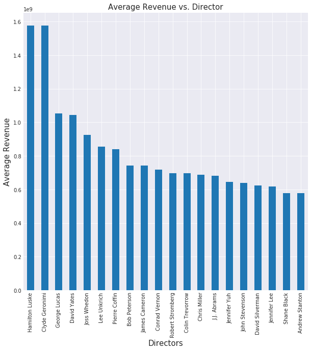

```python
#Visualizing our data
directors_revenue.plot(kind= 'bar', figsize= (10,10), legend=False);
plt.xlabel('Directors', fontsize = 15)
plt.ylabel('Average Revenue', fontsize = 15)
plt.title("Average Revenue vs. Director", fontsize = 15);
```

```python
#Show rows of Hamilton Luske and Clyde Geronimi
df_directors[(df_directors['director'] == 'Hamilton Luske') | (df_directors['director'] == 'Clyde Geronimi') ]
```

|  | popularity | original_title | cast | director | runtime | genres | production_companies | release_date | vote_count | vote_average | release_year | budget_adj | revenue_adj |
| --- | --- | --- | --- | --- | --- | --- | --- | --- | --- | --- | --- | --- | --- |
| 9050 | 2.631987 | One Hundred and One Dalmatians - 1961 | [Rod Taylor, J. Pat O'Malley, Betty Lou Gerson... | Clyde Geronimi | 79 | [Adventure, Animation, Comedy, Family] | [Walt Disney Productions] | 1961-01-25 | 913 | 6.6 | 1961 | 2.917944e+07 | 1.574815e+09 |
| 9050 | 2.631987 | One Hundred and One Dalmatians - 1961 | [Rod Taylor, J. Pat O'Malley, Betty Lou Gerson... | Hamilton Luske | 79 | [Adventure, Animation, Comedy, Family] | [Walt Disney Productions] | 1961-01-25 | 913 | 6.6 | 1961 | 2.917944e+07 | 1.574815e+09 |

> Based on the previous both Director **Hamilton Luske and Clyde Geronimi** have the highest average revenue. Both have worked on the same movies that explains why they have the same average value.

### 5. What production companies has the highest revenue?

```python
#Create df_company as a copy of df_cleaned then we use pandas.DataFrame.explode
df_company = df_cleaned.copy()
```

```python
#explode method to transform each company of production companies to a row
df_company = df_company.explode('production_companies')
df_company.head()
```

|  | popularity | original_title | cast | director | runtime | genres | production_companies | release_date | vote_count | vote_average | release_year | budget_adj | revenue_adj |
| --- | --- | --- | --- | --- | --- | --- | --- | --- | --- | --- | --- | --- | --- |
| 0 | 32.985763 | Jurassic World - 2015 | [Chris Pratt, Bryce Dallas Howard, Irrfan Khan... | [Colin Trevorrow] | 124 | [Action, Adventure, Science Fiction, Thriller] | Universal Studios | 2015-06-09 | 5562 | 6.5 | 2015 | 1.379999e+08 | 1.392446e+09 |
| 0 | 32.985763 | Jurassic World - 2015 | [Chris Pratt, Bryce Dallas Howard, Irrfan Khan... | [Colin Trevorrow] | 124 | [Action, Adventure, Science Fiction, Thriller] | Amblin Entertainment | 2015-06-09 | 5562 | 6.5 | 2015 | 1.379999e+08 | 1.392446e+09 |
| 0 | 32.985763 | Jurassic World - 2015 | [Chris Pratt, Bryce Dallas Howard, Irrfan Khan... | [Colin Trevorrow] | 124 | [Action, Adventure, Science Fiction, Thriller] | Legendary Pictures | 2015-06-09 | 5562 | 6.5 | 2015 | 1.379999e+08 | 1.392446e+09 |
| 0 | 32.985763 | Jurassic World - 2015 | [Chris Pratt, Bryce Dallas Howard, Irrfan Khan... | [Colin Trevorrow] | 124 | [Action, Adventure, Science Fiction, Thriller] | Fuji Television Network | 2015-06-09 | 5562 | 6.5 | 2015 | 1.379999e+08 | 1.392446e+09 |
| 0 | 32.985763 | Jurassic World - 2015 | [Chris Pratt, Bryce Dallas Howard, Irrfan Khan... | [Colin Trevorrow] | 124 | [Action, Adventure, Science Fiction, Thriller] | Dentsu | 2015-06-09 | 5562 | 6.5 | 2015 | 1.379999e+08 | 1.392446e+09 |

```python
#Group by production_companies and using aggregation of revenue mean
company_revenue = df_company.groupby('production_companies').revenue_adj.agg(avg_revenue= 'mean')
#Sort company_revenue in descending order to get top 10 production companies
company_revenue = company_revenue.sort_values(by= 'avg_revenue', ascending= False)
#Top 10 production companies according to their average revenue
company_revenue = company_revenue.iloc[0:10]
company_revenue
```

| production_companies | avg_revenue |
| --- | --- |
| Hoya Productions | 2.167325e+09 |
| Truenorth Productions | 1.902723e+09 |
| Alfran Productions | 1.277914e+09 |
| Julia Phillips and Michael Phillips Productions | 1.092965e+09 |
| Second Mate Productions | 1.081672e+09 |
| MIRACLE Productions GmbH & Co. KG | 1.062776e+09 |
| Disney Enterprises | 1.024887e+09 |
| Patalex IV Productions Limited | 1.000353e+09 |
| Lightstorm Entertainment | 9.899351e+08 |
| Cool Music | 9.866889e+08 |

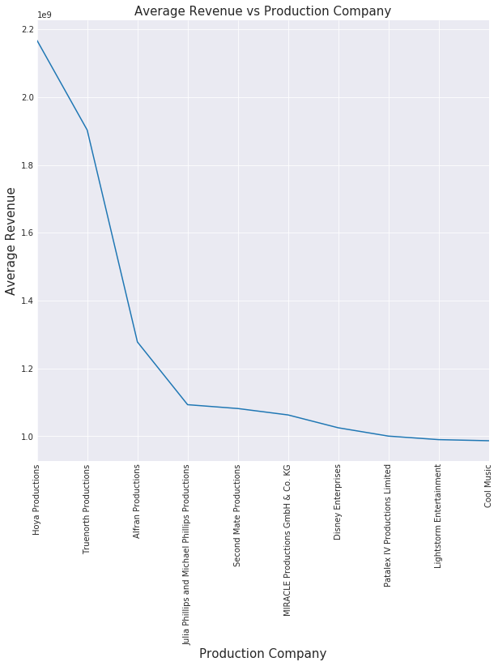

```python
#Visualizing our data
company_revenue.plot(kind= 'line', figsize= (10,10), legend=False);
plt.xlabel('Production Company', fontsize = 15)
plt.ylabel('Average Revenue', fontsize = 15)
plt.title("Average Revenue vs Production Company", fontsize = 15)
plt.xticks(rotation=90);
```

> Based on previous **Hoya Productions** has the highest average revenue of all production companies

### 6. What production company spend highest budget?

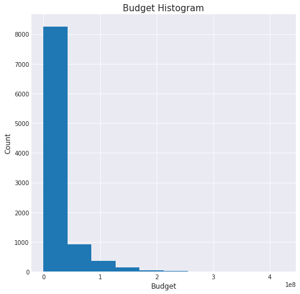

```python
#First lets plot a histogram showing budget distribution
#working with origianl cleanded data
df_cleaned['budget_adj'].hist(figsize= (8,8))
plt.xlabel('Budget', fontsize= 12)
plt.ylabel('Count', fontsize= 12)
plt.title('Budget Histogram',fontsize= 15);
```

```python
#View Statistical info about budget
df_cleaned['budget_adj'].describe()
```

```
count    9.772000e+03
mean     3.095978e+07
std      3.105834e+07
min      9.210911e-01
25%      2.267041e+07
50%      2.374361e+07
75%      2.464268e+07
max      4.250000e+08
Name: budget_adj, dtype: float64
```

> Based on the previous budget distribution appears to be right skewed.

```python
#Using df_company
#Group by production_companies and using aggregation of budget mean
company_budget = df_company.groupby('production_companies').budget_adj.agg(avg_budget= 'mean')
#Sort company_budget in descending order to get top 10 production companies
company_budget = company_budget.sort_values(by= 'avg_budget', ascending= False)
#Top 10 production companies according to their average budget spent
company_budget = company_budget.iloc[0:10]
company_budget
```

| production_companies | avg_budget |
| --- | --- |
| Boram Entertainment Inc. | 4.250000e+08 |
| Second Mate Productions | 2.659172e+08 |
| Silver Bullet Productions (II) | 2.386885e+08 |
| Blind Wink Productions | 2.386885e+08 |
| Big Primate Pictures | 2.311286e+08 |
| 3Foot7 | 2.302728e+08 |
| Ozumi Films | 2.278770e+08 |
| Propeler | 2.278770e+08 |
| B24 | 2.253999e+08 |
| Sonnenfeld Josephson Worldwide Entertainment | 2.225390e+08 |

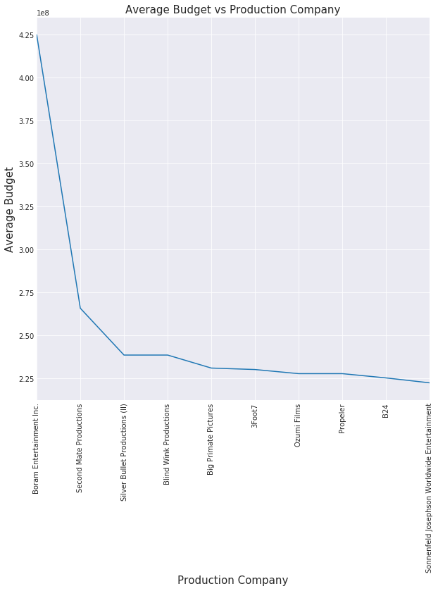

```python
#Visualizing our data
company_budget.plot(kind= 'line', figsize= (10,10), legend=False);
plt.xlabel('Production Company', fontsize = 15)
plt.ylabel('Average Budget', fontsize = 15)
plt.title("Average Budget vs Production Company", fontsize = 15)
plt.xticks(rotation=90);
```

### 7. Is higher budget movies associated with higher revenue?

```python
#Create df_corr as a copy of df_cleaned to work with
df_corr = df_cleaned.copy()
df_corr.head()
```

|  | popularity | original_title | cast | director | runtime | genres | production_companies | release_date | vote_count | vote_average | release_year | budget_adj | revenue_adj |
| --- | --- | --- | --- | --- | --- | --- | --- | --- | --- | --- | --- | --- | --- |
| 0 | 32.985763 | Jurassic World - 2015 | [Chris Pratt, Bryce Dallas Howard, Irrfan Khan... | [Colin Trevorrow] | 124 | [Action, Adventure, Science Fiction, Thriller] | [Universal Studios, Amblin Entertainment, Lege... | 2015-06-09 | 5562 | 6.5 | 2015 | 1.379999e+08 | 1.392446e+09 |
| 1 | 28.419936 | Mad Max: Fury Road - 2015 | [Tom Hardy, Charlize Theron, Hugh Keays-Byrne,... | [George Miller] | 120 | [Action, Adventure, Science Fiction, Thriller] | [Village Roadshow Pictures, Kennedy Miller Pro... | 2015-05-13 | 6185 | 7.1 | 2015 | 1.379999e+08 | 3.481613e+08 |
| 2 | 13.112507 | Insurgent - 2015 | [Shailene Woodley, Theo James, Kate Winslet, A... | [Robert Schwentke] | 119 | [Adventure, Science Fiction, Thriller] | [Summit Entertainment, Mandeville Films, Red W... | 2015-03-18 | 2480 | 6.3 | 2015 | 1.012000e+08 | 2.716190e+08 |
| 3 | 11.173104 | Star Wars: The Force Awakens - 2015 | [Harrison Ford, Mark Hamill, Carrie Fisher, Ad... | [J.J. Abrams] | 136 | [Action, Adventure, Science Fiction, Fantasy] | [Lucasfilm, Truenorth Productions, Bad Robot] | 2015-12-15 | 5292 | 7.5 | 2015 | 1.839999e+08 | 1.902723e+09 |
| 4 | 9.335014 | Furious 7 - 2015 | [Vin Diesel, Paul Walker, Jason Statham, Miche... | [James Wan] | 137 | [Action, Crime, Thriller] | [Universal Pictures, Original Film, Media Righ... | 2015-04-01 | 2947 | 7.3 | 2015 | 1.747999e+08 | 1.385749e+09 |

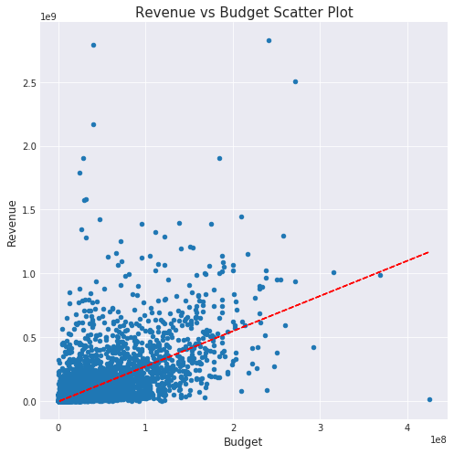

```python
#Plot a scatter plot between budget and revenue with trendline
x='budget_adj'
y='revenue_adj'
df_corr.plot(x, y, kind='scatter', figsize=(8,8))
plt.title('Revenue vs Budget Scatter Plot', fontsize= 15)
plt.xlabel('Budget', fontsize= 12)
plt.ylabel('Revenue', fontsize= 12)
z = np.polyfit(df_corr[x],df_corr[y], 1)
p = np.poly1d(z)
plt.plot(df_corr[x],p(df_corr[x]),'r--');
```

```python
#Calculate Correlation coeffecient
print('Correlation coeffecient value is {}'.format(df_corr[x].corr(df_corr[y])))
```

```
Correlation coeffecient value is 0.594560921510992
```

> Based on the previous scatter plot there is a **moderate linear positive correlation** between spent Budget and Revenue.

### 8. Is run time associated with revenue?

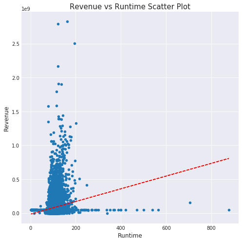

```python
#Plot a scatter plot between budget and revenue with trendline
x='runtime'
y='revenue_adj'
df_corr.plot(x, y, kind='scatter', figsize=(8,8))
plt.title('Revenue vs Runtime Scatter Plot', fontsize= 15)
plt.xlabel('Runtime', fontsize= 12)
plt.ylabel('Revenue', fontsize= 12)
z = np.polyfit(df_corr[x],df_corr[y], 1)
p = np.poly1d(z)
plt.plot(df_corr[x],p(df_corr[x]),'r--');
```

```python
##Calculate Correlation coeffecient
print('Correlation coeffecient value is {}'.format(df_corr[x].corr(df_corr[y])))
```

```
Correlation coeffecient value is 0.17989917293821778
```

> Based on the previous scatter plot and corrlation coeffecient there is a **weak linear positive correlation** between Runtime and Revenue but it may be neglected as it's weak.

### 9. Is there correlation between user’s vote average and revenue?

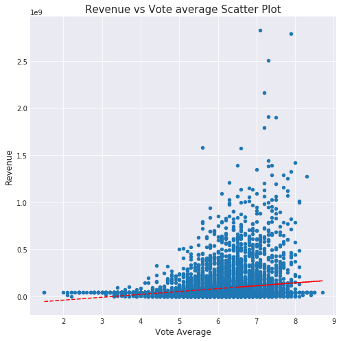

```python
#Plot a scatter plot between vote average and revenue with trendline
x='vote_average'
y='revenue_adj'
df_corr.plot(x, y, kind='scatter', figsize=(8,8))
plt.title('Revenue vs Vote average Scatter Plot', fontsize= 15)
plt.xlabel('Vote Average', fontsize= 12)
plt.ylabel('Revenue', fontsize= 12)
z = np.polyfit(df_corr[x],df_corr[y], 1)
p = np.poly1d(z)
plt.plot(df_corr[x],p(df_corr[x]),'r--');
```

```python
##Calculate Correlation coeffecient
print('Correlation coeffecient value is {}'.format(df_corr[x].corr(df_corr[y])))
```

```
Correlation coeffecient value is 0.1938619288595894
```

> Based on the previous scatter plot and corrlation coeffecient there is a **weak linear positive correlation** between user's Vote average and Revenue but it may be neglected as it's weak.

### 10. Is there correlation between popularity and revenue?

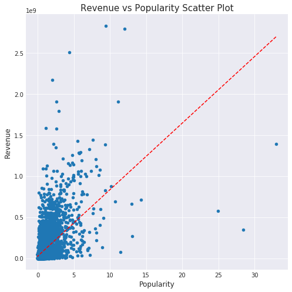

```python
#Plot a scatter plot between popularity and revenue with trendline
x='popularity'
y='revenue_adj'
df_corr.plot(x, y, kind='scatter', figsize=(8,8))
plt.title('Revenue vs Popularity Scatter Plot', fontsize= 15)
plt.xlabel('Popularity', fontsize= 12)
plt.ylabel('Revenue', fontsize= 12)
z = np.polyfit(df_corr[x],df_corr[y], 1)
p = np.poly1d(z)
plt.plot(df_corr[x],p(df_corr[x]),'r--');
```

```python
##Calculate Correlation coeffecient
print('Correlation coeffecient value is {}'.format(df_corr[x].corr(df_corr[y])))
```

```
Correlation coeffecient value is 0.5824995755189994
```

> Based on the previous scatter plot and corrlation coeffecient there is a **Moderate linear positive correlation** between Popularity and Revenue.

## Conclusions

> Mutliple findings from analysis of asked questions have led to the following conslusions:
> - Most popular movie genre is **Drama** followed by **Comedy** based on number of movies produced in each genre for the dataset time frame from 1960 till 2015. Additional information about numbers of sold tickets for each movies will be useful
> - **Adventure** is the genre with the highest average revenue followed by **Fantasy** then **Animation**. Additional information about age ratings for each movies will be useful
> - **Daisy Ridley** has the highest average revenue between actors followed by **Robert MacNaughton**.
> - **Hamilton Luske** and **Clyde Geronimi** have the highest average revenue between directors followed by **George Lucas**.  
>   **Hamilton Luske** and **Clyde Geronimi** worked together in the same movies and have the same average revenue.
> - **Hoya Productions** has the highest average revenue of all production companies followed by **Truenorth Productions**.
> - **Boram Entertainment Inc.** has the highest average budget of all production companies followed by **Second Mate Productions**
> - There is a **moderate linear positive correlation** between spent **Budget** and **Revenue**. Further statistical tests are needed to confirm correlation and its cause.
> - There is a **Moderate linear positive correlation** between **Popularity** and **Revenue**. Further statistical tests are needed to confirm correlation and its cause.
> - There is a **weak linear positive correlation** between **Runtime** and **Revenue** but it may be neglected as it's insignificant. This is also the case for the correlation between **vote average** and **Revenue**.

> Dataset and Analysis have limitations:
> - Dataset has many **unknown** and **missing** values as shown in Data Wrangling step
> - **Correlations found don't imply causation** and futher testing and analysis is needed
> - More information about **age ratings, for how long movie was in theaters and number of sold tickets for example** will be useful

```python
from subprocess import call
call(['python', '-m', 'nbconvert', 'Investigate_a_Dataset.ipynb'])
```

```
0
```